## Associations among morphotypes and species-specific genotypes around Kola Peninsular

Table ++. Parameters of regression models fitted

| Terms | Estimate | SE | z-statistic | p-value |
| --- | --- | --- | --- | --- |
| **Model 1** | $pseudo R^2$ = 0.38 |  |  |  |
| (Intercept) | -2.7 | 0.15 | -18.23 | < 0.001 |
| Ptros | 4.7 | 0.28 | 16.58 | < 0.001 |
| Subset(BL) | 0.2 | 0.26 | 0.62 | 0.537 |
| Subset(BH) | 2.2 | 0.19 | 11.30 | < 0.001 |
| Ptros:Subset(BL) | -0.5 | 0.45 | -1.03 | 0.302 |
| Ptros:Subset(BH) | -1.4 | 0.43 | -3.38 | 0.001 |
| **Model 2** | $pseudo R^2_{m}$ = 0.57 | $pseudo R^2_{c}$ = 0.64 |  |  |
| (Intercept) | -4.2 | 0.38 | -10.89 | < 0.001 |
| Ptros | 4.7 | 0.82 | 5.80 | < 0.001 |
| Subset(BL) | 0.3 | 0.75 | 0.40 | 0.688 |
| Subset(BH) | 3.5 | 0.57 | 6.18 | < 0.001 |
| Species(*M.trossulus*) | 4.2 | 0.45 | 9.34 | < 0.001 |
| Ptros:Subset(BL) | -1.9 | 1.51 | -1.24 | 0.214 |
| Ptros:Subset(BH) | -1.8 | 1.29 | -1.36 | 0.174 |
| Ptros:Species(*M.trossulus*) | -2.5 | 0.83 | -3.02 | 0.003 |
| Subset(BL):Species(*M.trossulus*) | -0.5 | 0.77 | -0.61 | 0.54 |
| Subset(BH):Species(*M.trossulus*) | -3 | 0.62 | -4.87 | < 0.001 |
| Ptros:Subset(BL):Species(*M.trossulus*) | 2.2 | 1.46 | 1.52 | 0.129 |
| Ptros:Subset(BH):Species(*M.trossulus*) | 2.5 | 1.25 | 1.96 | 0.05 |
| sd_(Intercept).pop | 0.8 |  |  |  |
| **Model 3** | $pseudo R^2$ = 0.17 |  |  |  |
| (Intercept) | 2.6 | 0.16 | 16.58 | < 0.001 |
| Ptros | -1.9 | 0.28 | -6.82 | < 0.001 |
| Subset(BL) | -0.4 | 0.28 | -1.53 | 0.127 |
| Subset(BH) | -2.4 | 0.2 | -12.29 | < 0.001 |
| Ptros:Subset(BL) | 1.1 | 0.47 | 2.26 | 0.024 |
| Ptros:Subset(BH) | 2.6 | 0.39 | 6.66 | < 0.001 |
| **Model 4** | $pseudo R^2_{m}$ = 0.4 | $pseudo R^2_{c}$ = 0.42 |  |  |
| (Intercept) | 3.8 | 0.28 | 13.99 | < 0.001 |

[output cut: 74 more lines]

## The value of morphotype-test for prediction of mussel’s taxa around Kola Peninsular

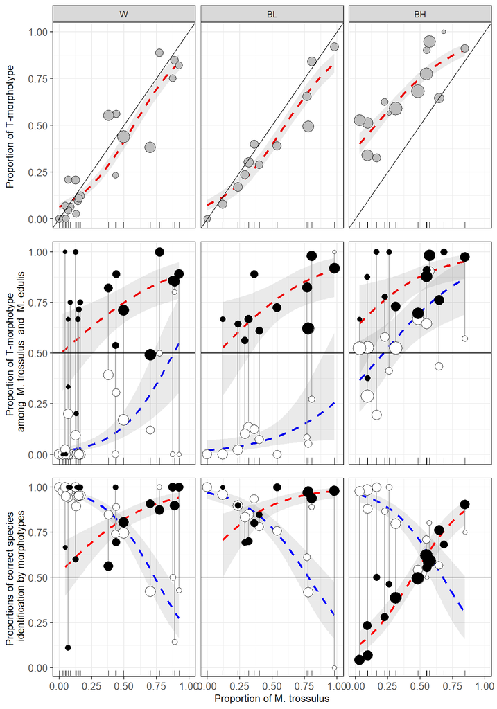

Figure ++. Variation of PT, P(T|tros), P(E|edu), P(tros|T), P(edu|E) as functions of Ptros in the White Sea (WS), brackish Barents Sea (BL) and saline Barents Sea (BH). Points - empirical estimates, size is proportional to sample sizes. Lines – regression model predictions, grey filling – 95% confidence intervals of regressions. (A) Proportions of T-morphotypes (PT) (Model 1). (B). Proportions of T-morphotypes among M. trossulus (filled points) and M. edulis (empty points) (Model 2). (C) Frequencies of M. trossulus among T-morphotypes (filled points) and of M. edulis among E-morphotypes (Model 4). Vertical lines on B and C connect subsamples of *M. trossulus* and *M. edulis* from the same samples.

Для параноиков. Таблицы с оценкой статистической значимости связи вероятности встретить Т-морфотип с размером

**Для M.trossulus**

| pop | term | estimate | std.error | statistic | p.value | p_adj |
| --- | --- | --- | --- | --- | --- | --- |
| abram | size | -0.1108248 | 8.944830e-02 | -1.2389827 | 0.2154 | 1.0000 |
| banka | size | 0.0228602 | 8.021860e-02 | 0.2849741 | 0.7757 | 1.0000 |
| belok | size | 0.0181256 | 4.231480e-02 | 0.4283507 | 0.6684 | 1.0000 |
| belok2 | size | -0.0442341 | 2.742920e-02 | -1.6126654 | 0.1068 | 1.0000 |
| Berg_new | size | -0.1097372 | 5.619000e-02 | -1.9529682 | 0.0508 | 1.0000 |
| Bergen_MV | size | -0.1008587 | 2.056170e-02 | -4.9051675 | 0.0000 | 0.0000 |
| Bergen04 | size | -0.0317087 | 1.865130e-01 | -0.1700077 | 0.8650 | 1.0000 |
| berzakol | size | 0.4532150 | 7.388397e-01 | 0.6134145 | 0.5396 | 1.0000 |
| bukhtovka | size | 0.4250105 | 3.242314e-01 | 1.3108246 | 0.1899 | 1.0000 |
| CBCP | size | 0.0000000 | 9.681266e+03 | 0.0000000 | 1.0000 | 1.0000 |
| CBE | size | 0.0928196 | 6.994610e-02 | 1.3270169 | 0.1845 | 1.0000 |
| CBSC | size | 0.0000000 | 1.028704e+04 | 0.0000000 | 1.0000 | 1.0000 |
| CBSL | size | 0.1843246 | 1.162855e-01 | 1.5851044 | 0.1129 | 1.0000 |
| chupa | size | 0.0388994 | 3.553700e-02 | 1.0946194 | 0.2737 | 1.0000 |
| dz_banka | size | -0.0542257 | 1.170614e-01 | -0.4632244 | 0.6432 | 1.0000 |
| dz_lit | size | -6.0847916 | 1.397308e+04 | -0.0004355 | 0.9997 | 1.0000 |
| Esp_MV | size | -0.3247392 | 9.102498e-01 | -0.3567583 | 0.7213 | 1.0000 |
| Esp04 | size | 0.0000000 | 8.584261e+03 | 0.0000000 | 1.0000 | 1.0000 |
| fr | size | -0.2108958 | 1.094794e-01 | -1.9263522 | 0.0541 | 1.0000 |
| ivan_buy | size | 0.0000001 | 5.707044e+03 | 0.0000000 | 1.0000 | 1.0000 |
| ivan_us | size | 0.0000000 | 5.113939e+03 | 0.0000000 | 1.0000 | 1.0000 |
| ivan2 | size | 0.3252129 | 7.520373e-01 | 0.4324425 | 0.6654 | 1.0000 |
| ivan3 | size | -0.0117252 | 3.013270e-02 | -0.3891189 | 0.6972 | 1.0000 |
| kanal | size | 0.0234291 | 5.116700e-02 | 0.4578946 | 0.6470 | 1.0000 |
| kast05 | size | 0.0000000 | 1.431588e+04 | 0.0000000 | 1.0000 | 1.0000 |
| kast87 | size | -0.1083427 | 1.216691e-01 | -0.8904703 | 0.3732 | 1.0000 |
| kovda | size | 0.4828767 | 4.098653e-01 | 1.1781353 | 0.2387 | 1.0000 |
| kuvsh | size | -0.0228386 | 1.002985e-01 | -0.2277059 | 0.8199 | 1.0000 |
| LE | size | 0.0000000 | 1.334664e+04 | 0.0000000 | 1.0000 | 1.0000 |
| Limh08 | size | -0.0444674 | 8.325400e-02 | -0.5341168 | 0.5933 | 1.0000 |
| Limh88 | size | 0.0985738 | 1.257655e-01 | 0.7837910 | 0.4332 | 1.0000 |
| luv_korg | size | -3.0885802 | 6.245287e+03 | -0.0004945 | 0.9996 | 1.0000 |
| luv_mat | size | 0.0000000 | 8.033788e+03 | 0.0000000 | 1.0000 | 1.0000 |
| MDRE | size | 0.0000000 | 1.170354e+04 | 0.0000000 | 1.0000 | 1.0000 |
| MDRW | size | 0.1805985 | 1.986924e-01 | 0.9089352 | 0.3634 | 1.0000 |
| mi | size | 0.0337182 | 2.652330e-02 | 1.2712640 | 0.2036 | 1.0000 |
| niva_sl | size | 33.3162751 | 1.573704e+04 | 0.0021171 | 0.9983 | 1.0000 |
| nm_last | size | -0.1699536 | 1.100788e-01 | -1.5439272 | 0.1226 | 1.0000 |
| oenij | size | -0.0497075 | 4.413490e-02 | -1.1262646 | 0.2601 | 1.0000 |
| PL | size | 0.0457526 | 1.251185e-01 | 0.3656738 | 0.7146 | 1.0000 |
| porya | size | 0.1093742 | 1.445263e-01 | 0.7567767 | 0.4492 | 1.0000 |
| rya | size | 0.0485582 | 5.827710e-02 | 0.8332296 | 0.4047 | 1.0000 |
| salnij | size | -0.0581087 | 6.505810e-02 | -0.8931819 | 0.3718 | 1.0000 |
| seredina | size | -0.0486490 | 1.029052e-01 | -0.4727556 | 0.6364 | 1.0000 |
| seredina_sub | size | -0.1112264 | 4.070950e-02 | -2.7321961 | 0.0063 | 0.4032 |
| sevsk | size | -0.0415182 | 5.477780e-02 | -0.7579380 | 0.4485 | 1.0000 |
| Solvesborg | size | 0.0500393 | 9.505030e-02 | 0.5264510 | 0.5986 | 1.0000 |
| tu_old | size | 0.0677881 | 8.934310e-02 | 0.7587384 | 0.4480 | 1.0000 |
| umba | size | -0.0521419 | 3.394190e-02 | -1.5362109 | 0.1245 | 1.0000 |
| umba_pikut | size | -0.0681524 | 1.837586e-01 | -0.3708799 | 0.7107 | 1.0000 |
| umba_pil | size | 0.0000000 | 6.935617e+03 | 0.0000000 | 1.0000 | 1.0000 |
| umba_sovhoz | size | -0.2278249 | 2.892604e-01 | -0.7876118 | 0.4309 | 1.0000 |
| ustie | size | -0.0541400 | 6.392150e-02 | -0.8469766 | 0.3970 | 1.0000 |
| ustie_sub | size | -0.0563161 | 2.210170e-02 | -2.5480402 | 0.0108 | 0.6804 |
| Vhg05 | size | -0.2906209 | 2.303068e-01 | -1.2618858 | 0.2070 | 1.0000 |
| Vhg88 | size | 0.0459479 | 4.954360e-02 | 0.9274233 | 0.3537 | 1.0000 |
| vol | size | 0.0244604 | 3.342290e-02 | 0.7318447 | 0.4643 | 1.0000 |
| vor1 | size | -3.8566784 | 7.148998e+03 | -0.0005395 | 0.9996 | 1.0000 |
| vor2 | size | 0.0000000 | 1.677257e+04 | 0.0000000 | 1.0000 | 1.0000 |
| vor5 | size | 0.0000000 | 1.677258e+04 | 0.0000000 | 1.0000 | 1.0000 |
| voronya | size | -20.5066666 | 3.084329e+04 | -0.0006649 | 0.9995 | 1.0000 |
| yarn02 | size | -0.0000001 | 1.504645e+04 | 0.0000000 | 1.0000 | 1.0000 |
| yokanga | size | 0.0500410 | 8.065630e-02 | 0.6204234 | 0.5350 | 1.0000 |
| Ystad05 | size | -0.1691679 | 7.659470e-02 | -2.2086115 | 0.0272 | 1.0000 |
| zmis | size | 0.3348717 | 5.393720e-01 | 0.6208549 | 0.5347 | 1.0000 |

**Для M.edulis**

| pop | term | estimate | std.error | statistic | p.value | p_adj |
| --- | --- | --- | --- | --- | --- | --- |
| abram | size | 0.0348846 | 9.983410e-02 | 0.3494260 | 0.7268 | 1.0000 |
| banka | size | -0.0841483 | 2.227860e-02 | -3.7770844 | 0.0002 | 0.0144 |
| belok | size | 0.1327493 | 5.183180e-02 | 2.5611567 | 0.0104 | 0.7280 |
| Berg_new | size | 0.0000000 | 1.057923e+04 | 0.0000000 | 1.0000 | 1.0000 |
| Bergen_MV | size | -0.0347578 | 4.661700e-02 | -0.7456029 | 0.4559 | 1.0000 |
| Bergen04 | size | 0.0000000 | 8.725781e+03 | 0.0000000 | 1.0000 | 1.0000 |
| berzakol | size | 0.0000000 | 8.535401e+03 | 0.0000000 | 1.0000 | 1.0000 |
| BI | size | 0.0000000 | 1.476227e+04 | 0.0000000 | 1.0000 | 1.0000 |
| bukhtovka | size | 0.0466742 | 5.382040e-02 | 0.8672213 | 0.3858 | 1.0000 |
| CBCP | size | 0.0000000 | 7.394430e+03 | 0.0000000 | 1.0000 | 1.0000 |
| CBSC | size | 0.4864048 | 4.895929e-01 | 0.9934883 | 0.3205 | 1.0000 |
| CBSL | size | 0.0482970 | 1.757988e-01 | 0.2747290 | 0.7835 | 1.0000 |
| chupa | size | -0.0690996 | 7.600370e-02 | -0.9091603 | 0.3633 | 1.0000 |
| dz_banka | size | -0.0397191 | 2.144620e-02 | -1.8520382 | 0.0640 | 1.0000 |
| dz_lit | size | -0.0134375 | 2.930620e-02 | -0.4585212 | 0.6466 | 1.0000 |
| Esp_MV | size | -0.0035052 | 5.255970e-02 | -0.0666892 | 0.9468 | 1.0000 |
| Esp04 | size | 0.0000000 | 1.272473e+04 | 0.0000000 | 1.0000 | 1.0000 |
| fr | size | -0.1333515 | 7.624670e-02 | -1.7489481 | 0.0803 | 1.0000 |
| ivan_buy | size | 0.0000000 | 4.120860e+03 | 0.0000000 | 1.0000 | 1.0000 |
| ivan_us | size | -0.0789455 | 5.764080e-02 | -1.3696127 | 0.1708 | 1.0000 |
| ivan2 | size | 0.0000000 | 1.079564e+04 | 0.0000000 | 1.0000 | 1.0000 |
| ivan3 | size | -0.0515276 | 1.606121e-01 | -0.3208199 | 0.7483 | 1.0000 |
| JPC | size | 0.0268075 | 2.495171e-01 | 0.1074373 | 0.9144 | 1.0000 |
| kanal | size | 27.3190547 | 2.995682e+04 | 0.0009119 | 0.9993 | 1.0000 |
| kast05 | size | 0.0000000 | 4.801049e+03 | 0.0000000 | 1.0000 | 1.0000 |
| kast87 | size | -0.1805728 | 2.310627e-01 | -0.7814883 | 0.4345 | 1.0000 |
| KIM | size | -0.0018190 | 1.035430e-01 | -0.0175675 | 0.9860 | 1.0000 |
| kovda | size | 0.0000000 | 3.699468e+03 | 0.0000000 | 1.0000 | 1.0000 |
| kuvsh | size | 0.3147051 | 2.370035e-01 | 1.3278499 | 0.1842 | 1.0000 |
| LE | size | 0.0000000 | 7.619990e+03 | 0.0000000 | 1.0000 | 1.0000 |
| Limh08 | size | -0.1322596 | 1.875566e-01 | -0.7051720 | 0.4807 | 1.0000 |
| Limh88 | size | 0.0000000 | 1.153142e+04 | 0.0000000 | 1.0000 | 1.0000 |
| luv_korg | size | 0.0000000 | 1.227471e+04 | 0.0000000 | 1.0000 | 1.0000 |
| luv_mat | size | -0.1043326 | 1.234544e-01 | -0.8451105 | 0.3980 | 1.0000 |
| MDICOA | size | -6.6291247 | 4.693919e+03 | -0.0014123 | 0.9989 | 1.0000 |
| MDRE | size | 0.3647313 | 3.214035e-01 | 1.1348082 | 0.2565 | 1.0000 |
| MDRW | size | -0.0855364 | 1.557831e-01 | -0.5490735 | 0.5830 | 1.0000 |
| mi | size | 0.0379692 | 1.291182e-01 | 0.2940655 | 0.7687 | 1.0000 |
| niva_sl | size | 0.1660846 | 9.957490e-02 | 1.6679361 | 0.0953 | 1.0000 |
| nm | size | 0.0000000 | 7.858943e+03 | 0.0000000 | 1.0000 | 1.0000 |
| nm_last | size | -0.0177127 | 4.662920e-02 | -0.3798640 | 0.7040 | 1.0000 |
| oenij | size | 0.0000000 | 1.161015e+04 | 0.0000000 | 1.0000 | 1.0000 |
| padan | size | 0.0000000 | 6.190601e+03 | 0.0000000 | 1.0000 | 1.0000 |
| PH | size | -0.0513918 | 9.269990e-02 | -0.5543886 | 0.5793 | 1.0000 |
| PL | size | 0.4477981 | 3.135296e-01 | 1.4282483 | 0.1532 | 1.0000 |
| porya | size | 0.0000000 | 3.231783e+03 | 0.0000000 | 1.0000 | 1.0000 |
| rya | size | 0.0628899 | 3.368810e-02 | 1.8668299 | 0.0619 | 1.0000 |
| salnij | size | 0.0000000 | 2.161082e+04 | 0.0000000 | 1.0000 | 1.0000 |
| seredina | size | -0.0526104 | 3.931170e-02 | -1.3382909 | 0.1808 | 1.0000 |
| seredina_sub | size | -0.0705725 | 2.411950e-02 | -2.9259487 | 0.0034 | 0.2414 |
| sevsk | size | 0.0000000 | 9.079304e+03 | 0.0000000 | 1.0000 | 1.0000 |
| tu_old | size | -0.0383189 | 9.161670e-02 | -0.4182527 | 0.6758 | 1.0000 |
| umba | size | -0.1243559 | 7.302580e-02 | -1.7029035 | 0.0886 | 1.0000 |
| umba_06 | size | 0.0000000 | 6.594840e+03 | 0.0000000 | 1.0000 | 1.0000 |
| umba_bridge | size | 0.0000000 | 8.818480e+03 | 0.0000000 | 1.0000 | 1.0000 |
| umba_kamni | size | 0.0000000 | 1.183647e+04 | 0.0000000 | 1.0000 | 1.0000 |
| umba_pikut | size | 0.0000000 | 5.299659e+03 | 0.0000000 | 1.0000 | 1.0000 |
| umba_pil | size | 0.1629761 | 1.999680e-01 | 0.8150110 | 0.4151 | 1.0000 |
| umba_pioner | size | 0.0000000 | 8.159787e+03 | 0.0000000 | 1.0000 | 1.0000 |
| umba_sovhoz | size | 0.0000000 | 6.172554e+03 | 0.0000000 | 1.0000 | 1.0000 |
| ustie | size | -0.0354519 | 4.461180e-02 | -0.7946757 | 0.4268 | 1.0000 |
| ustie_sub | size | -0.1009798 | 2.352760e-02 | -4.2919668 | 0.0000 | 0.0000 |
| VH | size | 0.0000000 | 1.113020e+04 | 0.0000000 | 1.0000 | 1.0000 |
| Vhg05 | size | 0.0000000 | 8.399645e+03 | 0.0000000 | 1.0000 | 1.0000 |
| Vhg88 | size | 0.0849415 | 1.601970e-01 | 0.5302314 | 0.5960 | 1.0000 |
| vol | size | 0.0510169 | 4.593410e-02 | 1.1106540 | 0.2667 | 1.0000 |
| vor1 | size | 0.0179428 | 5.879810e-02 | 0.3051587 | 0.7602 | 1.0000 |
| vor2 | size | 0.0000000 | 9.819141e+03 | 0.0000000 | 1.0000 | 1.0000 |
| vor5 | size | 0.0068308 | 1.325602e-01 | 0.0515297 | 0.9589 | 1.0000 |
| voronya | size | 0.0000000 | 6.170223e+03 | 0.0000000 | 1.0000 | 1.0000 |
| yarn02 | size | -0.0150716 | 1.314686e-01 | -0.1146400 | 0.9087 | 1.0000 |
| yokanga | size | -0.0348270 | 1.553357e-01 | -0.2242048 | 0.8226 | 1.0000 |
| zmis | size | 0.1204233 | 1.517257e-01 | 0.7936907 | 0.4274 | 1.0000 |

## Associations between phenotypic and genotypic structure of populations around Atlantics

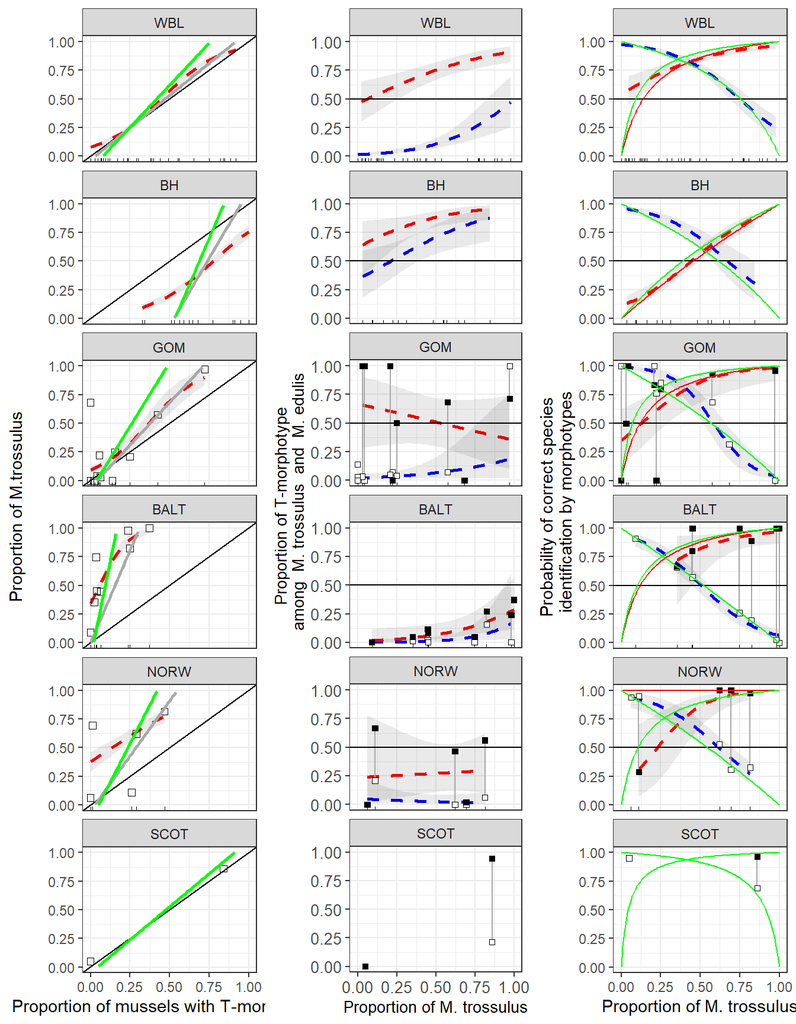

Table ++. Predicted values of probability of correct species identification by mussel morphotype in mixed populations (Ptros = 0.5) in different geographical regions. Low and upper boundaries of 95% conficencal intervals are given for predicted values.

| Subset | P(edu\|E) |  |  | P(tros\|T) |  |  |
| --- | --- | --- | --- | --- | --- | --- |
|  | Predicted | Low | Up | Predicted | Low | Up |
| WBL | 0.77 | 0.73 | 0.81 | 0.85 | 0.82 | 0.89 |
| BH | 0.7 | 0.61 | 0.78 | 0.57 | 0.51 | 0.63 |
| GOM | 0.66 | 0.54 | 0.77 | 0.86 | 0.68 | 0.95 |
| BALT | 0.51 | 0.44 | 0.58 | 0.82 | 0.58 | 0.94 |
| NORW | 0.64 | 0.53 | 0.74 | 0.86 | 0.68 | 0.95 |

Table +. Proportion of mussels correctly identified by morphotype test in different regions

| Region | E-morphotype as M.edulis | T-morphotype as M.trossulus |
| --- | --- | --- |
| WBL | 0.74 | 0.72 |
| BH | 0.76 | 0.02 |
| GOM | 0.82 | 0.62 |
| BALT | 0.00 | 0.81 |
| NORW | 0.00 | 0.92 |

## Using the probability theory equation (Eq 1, 2, 3) for express assessments by morphotype test

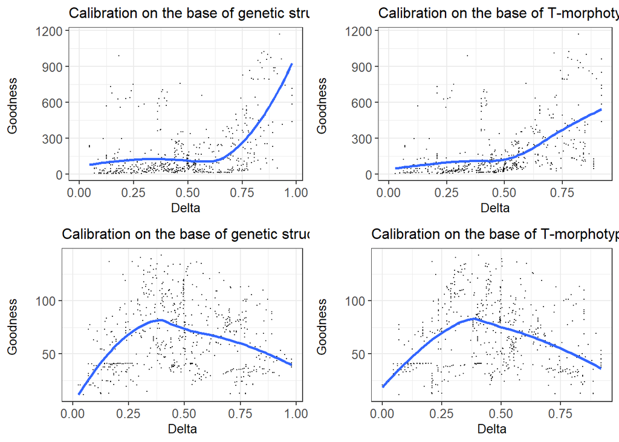

Figure +. Correspondence between regression and theoretical models. Each point corresponds to one of the possible pairs of populations from modelling data set (White Sea joined with low salinity Barens Sea). OX axis represents the differencу in genetic structre for each pair of populations. OY axis represents correspondence between prediction of regression model and theoretical model. Lines represent LOESS-smoother. (A ) Model 7 describing the dependence of proportion of M.trossulus (Ptros) on proportion of T-morphotype (P_T) ; (B) Model 6 describing the dependence of probability of correct species identification on proportion of M.trossulus and morphotype.

## Формулы для моделей

[output not shown]

## К разделу “Practical recomendations”

СВою задачу я понял так: понять какой тип калибровочных выборок даст наилучшее соответсвие между наблюдаемыми величинами и предсказанными калькулятором, если на входе исслдватель имеет данные по морфотипам и может генотиприровать только ограниченное количество выборок.

Для этого анализа я оставил только WBL. Можно включить и остальные датасеты, но, мне кажется, что так проще разобраться. При этом, ход анализа я максимально приблизил к боевым условиям, т.е. для выбора калибровочных сборов я использовал информацию о частоте Т-морфортипа, а не не генетической структуре, которая для начального исследования неизвестна. Соответственно, для калибровочных бубликов использованы три варианта: 1. Максимально различные по частоте Т-морфотипа выборки (diff); 2. Максимально смешанные выборки (mix) частота T-морфотипа близка к 0.5; 3. Все имеющиеся выборки (all).

Всплыли следующие проблемы.

0. Как уже обсуждалось, часть выборок вылетают из анализа, так как калькулятор предсказывает для них предсказанные значения Ptros_Eq<0 или Ptros_Eq>1. При разных вариантах формирования калибровочной выборки количество отброшенных получается разным.
1. Статистики (все которые я пробовал) дают ответ, не укладывающийся в нашу гипотезу о том, что для оценки бубликов для вычисления Ptros как функции от PT лучше брать максимально различные калибровочные выборки. На графиках сейчас приведены суммы квадратов разниц между наблюдаемой величиной и величиной, предсказанной калькулятором. Это получается из-за того, что разное количество краевых выборок откидывается (Ptros_Eq<0 или Ptros_Eq>1). Это приводит к тому, что в анализе остаются только самые “лучшие” выборки, которые и дают наиболее хорошее соответствие наблюдаемого и предсказанного.
2. При вычислении P(tros|T) и P(edu|E) пришлось рассмотреть 9(!) комбинаций калибровочных выборок. Они маркированы в заголовке графика, на первом месте стоит тип калибровочной выборки, использованной для Ptros_Eq, а на втором месте тип выборки, использованной для вычисления P(tros|T) и P(edu|E). Линии регрессии позволяют рассмотреть общий ход облака точек. Видно, что для edu все ОК (точки хорошо лежат около Y=X), но в случае tros все не так. Здесь гадят те точки, у которых наблюдаемая Ptros равна 1, а предсказанная калькулятором Ptros_eq пляшет в широких пределах. Что с этим делать не знаю.

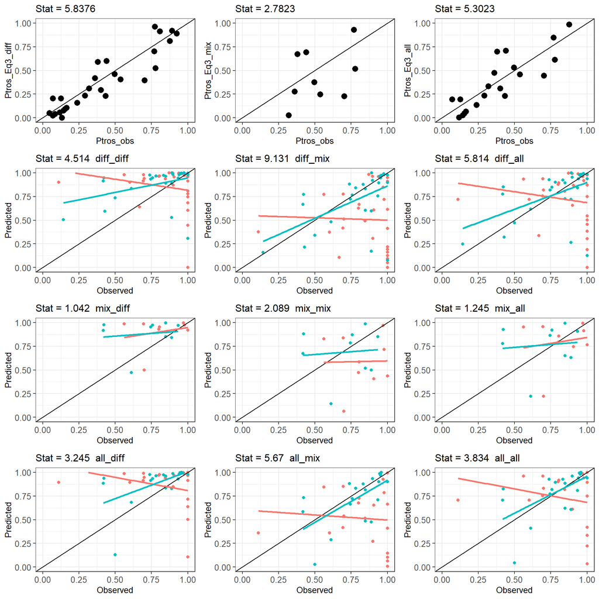

Вот исходники можешь покопаться сам

Calibration on the base of T-morphotype frequency

| pop | PT | Ptros_obs | Ptros_Eq3_diff | Ptros_Eq3_mix | Ptros_Eq3_all | P_MT_T_Eq1_diff_diff | P_MT_T_Eq1_diff_mix | P_MT_T_Eq1_diff_all | P_MT_T_Eq1_mix_diff | P_MT_T_Eq1_mix_mix | P_MT_T_Eq1_mix_all | P_MT_T_Eq1_all_diff | P_MT_T_Eq1_all_mix | P_MT_T_Eq1_all_all | P_ME_E_Eq2_diff_diff | P_ME_E_Eq2_diff_mix | P_ME_E_Eq2_diff_all | P_ME_E_Eq2_mix_diff | P_ME_E_Eq2_mix_mix | P_ME_E_Eq2_mix_all | P_ME_E_Eq2_all_diff | P_ME_E_Eq2_all_mix | P_ME_E_Eq2_all_all | P_MT_T_obs | P_ME_E_obs | max_mix | max_dif | Set |
| --- | --- | --- | --- | --- | --- | --- | --- | --- | --- | --- | --- | --- | --- | --- | --- | --- | --- | --- | --- | --- | --- | --- | --- | --- | --- | --- | --- | --- |
| abram | 0.289 | 0.400 | 0.294 | - | 0.312 | 0.936 | 0.493 | 0.806 | - | - | - | 0.941 | 0.514 | 0.819 | 0.966 | 0.842 | 0.902 | - | - | - | 0.963 | 0.830 | 0.894 | 0.846 | 0.781 | 0 | 0 | WBL |
| belok | 0.303 | 0.318 | 0.310 | 0.028 | 0.333 | 0.940 | 0.512 | 0.817 | 0.498 | 0.062 | 0.220 | 0.946 | 0.537 | 0.832 | 0.964 | 0.831 | 0.895 | 0.998 | 0.987 | 0.993 | 0.960 | 0.817 | 0.885 | 0.700 | 0.848 | 0 | 0 | WBL |
| belok2 | 0.920 | 0.980 | - | - | - | - | - | - | - | - | - | - | - | - | - | - | - | - | - | - | - | - | - | 0.978 | 0.000 | 0 | 1 | WBL |
| berzakol | 0.064 | 0.085 | 0.042 | - | - | 0.605 | 0.093 | 0.304 | - | - | - | - | - | - | 0.996 | 0.981 | 0.989 | - | - | - | - | - | - | 1.000 | 0.977 | 0 | 0 | WBL |
| chupa | 0.381 | 0.702 | 0.398 | 0.228 | 0.447 | 0.958 | 0.606 | 0.868 | 0.912 | 0.408 | 0.746 | 0.966 | 0.653 | 0.889 | 0.948 | 0.771 | 0.853 | 0.976 | 0.882 | 0.928 | 0.937 | 0.733 | 0.826 | 0.906 | 0.423 | 0 | 0 | WBL |
| fr | 0.236 | 0.291 | 0.235 | - | 0.235 | 0.915 | 0.418 | 0.754 | - | - | - | 0.915 | 0.417 | 0.754 | 0.975 | 0.878 | 0.925 | - | - | - | 0.975 | 0.878 | 0.926 | 0.692 | 0.833 | 0 | 0 | WBL |
| ivan2 | 0.078 | 0.118 | 0.058 | - | 0.003 | 0.684 | 0.126 | 0.382 | - | - | - | 0.105 | 0.008 | 0.033 | 0.995 | 0.973 | 0.984 | - | - | - | 1.000 | 0.998 | 0.999 | 1.000 | 0.957 | 0 | 0 | WBL |
| ivan3 | 0.654 | 0.769 | 0.703 | 0.930 | 0.847 | 0.988 | 0.847 | 0.959 | 0.998 | 0.969 | 0.993 | 0.995 | 0.928 | 0.982 | 0.834 | 0.483 | 0.617 | 0.471 | 0.142 | 0.222 | 0.683 | 0.286 | 0.409 | 0.971 | 0.611 | 0 | 0 | WBL |
| kanal | 0.848 | 0.891 | 0.921 | - | - | 0.998 | 0.964 | 0.991 | - | - | - | - | - | - | 0.506 | 0.160 | 0.247 | - | - | - | - | - | - | 0.897 | 0.143 | 0 | 0 | WBL |
| kovda | 0.122 | 0.163 | 0.108 | - | 0.068 | 0.808 | 0.220 | 0.546 | - | - | - | 0.718 | 0.145 | 0.420 | 0.990 | 0.948 | 0.969 | - | - | - | 0.994 | 0.968 | 0.981 | 1.000 | 0.953 | 0 | 0 | WBL |
| luv_korg | 0.047 | 0.070 | 0.023 | - | - | 0.447 | 0.051 | 0.187 | - | - | - | - | - | - | 0.998 | 0.990 | 0.994 | - | - | - | - | - | - | 1.000 | 0.976 | 0 | 0 | WBL |
| luv_mat | 0.208 | 0.125 | 0.204 | - | 0.194 | 0.899 | 0.374 | 0.719 | - | - | - | 0.893 | 0.359 | 0.705 | 0.979 | 0.896 | 0.937 | - | - | - | 0.980 | 0.902 | 0.941 | 0.600 | 1.000 | 0 | 0 | WBL |
| mi | 0.494 | 0.776 | 0.524 | 0.519 | 0.613 | 0.975 | 0.720 | 0.917 | 0.974 | 0.716 | 0.915 | 0.982 | 0.787 | 0.940 | 0.915 | 0.668 | 0.776 | 0.917 | 0.672 | 0.780 | 0.883 | 0.584 | 0.707 | 0.976 | 0.419 | 1 | 0 | WBL |
| niva_sl | 0.561 | 0.439 | 0.599 | 0.691 | 0.711 | 0.981 | 0.777 | 0.937 | 0.987 | 0.839 | 0.957 | 0.988 | 0.851 | 0.961 | 0.889 | 0.597 | 0.719 | 0.842 | 0.497 | 0.630 | 0.829 | 0.474 | 0.609 | 0.696 | 0.889 | 0 | 0 | WBL |
| nm | 0.000 | 0.000 | - | - | - | - | - | - | - | - | - | - | - | - | - | - | - | - | - | - | - | - | - | - | 1.000 | 0 | 1 | WBL |
| nm_last | 0.400 | 0.360 | 0.419 | 0.277 | 0.475 | 0.962 | 0.627 | 0.878 | 0.930 | 0.472 | 0.793 | 0.969 | 0.678 | 0.900 | 0.943 | 0.755 | 0.841 | 0.969 | 0.853 | 0.909 | 0.930 | 0.710 | 0.809 | 0.800 | 0.933 | 0 | 0 | WBL |
| oenij | 0.750 | 0.875 | 0.811 | - | 0.988 | 0.993 | 0.909 | 0.977 | - | - | - | 1.000 | 0.995 | 0.999 | 0.735 | 0.340 | 0.471 | - | - | - | 0.129 | 0.027 | 0.045 | 1.000 | 0.500 | 0 | 0 | WBL |
| padan | 0.000 | 0.033 | - | - | - | - | - | - | - | - | - | - | - | - | - | - | - | - | - | - | - | - | - | - | 0.967 | 0 | 0 | WBL |
| porya | 0.095 | 0.143 | 0.077 | - | 0.028 | 0.745 | 0.163 | 0.455 | - | - | - | 0.501 | 0.063 | 0.223 | 0.993 | 0.964 | 0.979 | - | - | - | 0.998 | 0.987 | 0.993 | 1.000 | 0.947 | 0 | 0 | WBL |
| rya | 0.554 | 0.378 | 0.592 | 0.674 | 0.701 | 0.981 | 0.771 | 0.935 | 0.986 | 0.828 | 0.954 | 0.988 | 0.845 | 0.959 | 0.892 | 0.605 | 0.725 | 0.852 | 0.518 | 0.649 | 0.836 | 0.487 | 0.620 | 0.561 | 0.848 | 1 | 0 | WBL |
| salnij | 0.821 | 0.923 | 0.890 | - | - | 0.996 | 0.950 | 0.988 | - | - | - | - | - | - | 0.595 | 0.215 | 0.320 | - | - | - | - | - | - | 1.000 | 0.429 | 0 | 0 | WBL |
| sevsk | 0.389 | 0.537 | 0.406 | 0.249 | 0.458 | 0.960 | 0.615 | 0.872 | 0.920 | 0.435 | 0.767 | 0.967 | 0.663 | 0.894 | 0.946 | 0.764 | 0.848 | 0.973 | 0.870 | 0.920 | 0.934 | 0.724 | 0.819 | 1.000 | 0.758 | 0 | 0 | WBL |
| umba | 0.438 | 0.495 | 0.462 | 0.375 | 0.531 | 0.968 | 0.666 | 0.895 | 0.954 | 0.583 | 0.857 | 0.975 | 0.725 | 0.918 | 0.933 | 0.721 | 0.817 | 0.952 | 0.787 | 0.864 | 0.913 | 0.662 | 0.772 | 0.804 | 0.746 | 0 | 0 | WBL |
| umba_06 | 0.000 | 0.000 | - | - | - | - | - | - | - | - | - | - | - | - | - | - | - | - | - | - | - | - | - | - | 1.000 | 0 | 0 | WBL |
| umba_bridge | 0.000 | 0.000 | - | - | - | - | - | - | - | - | - | - | - | - | - | - | - | - | - | - | - | - | - | - | 1.000 | 0 | 0 | WBL |
| umba_kamni | 0.000 | 0.000 | - | - | - | - | - | - | - | - | - | - | - | - | - | - | - | - | - | - | - | - | - | - | 1.000 | 0 | 0 | WBL |
| umba_pikut | 0.233 | 0.433 | 0.232 | - | 0.230 | 0.913 | 0.413 | 0.751 | - | - | - | 0.913 | 0.411 | 0.749 | 0.975 | 0.880 | 0.927 | - | - | - | 0.976 | 0.881 | 0.927 | 1.000 | 0.739 | 0 | 0 | WBL |
| umba_pil | 0.886 | 0.773 | 0.964 | - | - | 0.999 | 0.984 | 0.996 | - | - | - | - | - | - | 0.307 | 0.076 | 0.125 | - | - | - | - | - | - | 0.872 | 1.000 | 0 | 0 | WBL |
| umba_pioner | 0.000 | 0.025 | - | - | - | - | - | - | - | - | - | - | - | - | - | - | - | - | - | - | - | - | - | - | 0.975 | 0 | 0 | WBL |
| umba_sovhoz | 0.026 | 0.132 | 0.000 | - | - | 0.000 | 0.000 | 0.000 | - | - | - | - | - | - | 1.000 | 1.000 | 1.000 | - | - | - | - | - | - | 1.000 | 0.892 | 0 | 0 | WBL |
| vor1 | 0.209 | 0.070 | 0.205 | - | 0.195 | 0.900 | 0.375 | 0.720 | - | - | - | 0.894 | 0.361 | 0.707 | 0.979 | 0.896 | 0.937 | - | - | - | 0.980 | 0.901 | 0.940 | 0.111 | 0.941 | 0 | 0 | WBL |
| vor2 | 0.000 | 0.051 | - | - | - | - | - | - | - | - | - | - | - | - | - | - | - | - | - | - | - | - | - | - | 0.949 | 0 | 0 | WBL |
| vor5 | 0.070 | 0.047 | 0.049 | - | - | 0.641 | 0.107 | 0.338 | - | - | - | - | - | - | 0.996 | 0.977 | 0.987 | - | - | - | - | - | - | 0.667 | 1.000 | 0 | 0 | WBL |
| voronya | 0.109 | 0.152 | 0.092 | - | 0.048 | 0.780 | 0.192 | 0.503 | - | - | - | 0.636 | 0.105 | 0.333 | 0.992 | 0.956 | 0.974 | - | - | - | 0.996 | 0.978 | 0.987 | 1.000 | 0.951 | 0 | 0 | WBL |
| yokanga | 0.169 | 0.237 | 0.161 | - | 0.137 | 0.870 | 0.308 | 0.656 | - | - | - | 0.847 | 0.270 | 0.612 | 0.984 | 0.921 | 0.952 | - | - | - | 0.987 | 0.933 | 0.960 | 0.900 | 0.898 | 0 | 0 | WBL |
| zmis | 0.842 | 0.807 | 0.915 | - | - | 0.997 | 0.961 | 0.991 | - | - | - | - | - | - | 0.527 | 0.172 | 0.263 | - | - | - | - | - | - | 0.938 | 0.889 | 0 | 0 | WBL |
| banka | 0.512 | 0.095 | 0.290 | 0.182 | - | 0.567 | 0.261 | 0.392 | 0.416 | 0.162 | 0.261 | - | - | - | 1.000 | 0.681 | 0.880 | 1.000 | 0.796 | 0.931 | - | - | - | 0.070 | 0.878 | 1 | 0 | BH |
| bukhtovka | 0.625 | 0.225 | 0.455 | - | 0.293 | 0.727 | 0.419 | 0.569 | - | - | - | 0.571 | 0.265 | 0.396 | 1.000 | 0.511 | 0.782 | - | - | - | 1.000 | 0.677 | 0.878 | 0.280 | 0.867 | 0 | 0 | BH |
| dz_banka | 0.341 | 0.091 | 0.041 | - | - | 0.121 | 0.036 | 0.064 | - | - | - | - | - | - | 1.000 | 0.953 | 0.986 | - | - | - | - | - | - | 0.233 | 0.983 | 0 | 0 | BH |
| dz_lit | 0.528 | 0.034 | 0.314 | - | - | 0.594 | 0.284 | 0.419 | - | - | - | - | - | - | 1.000 | 0.656 | 0.868 | - | - | - | - | - | - | 0.043 | 0.976 | 1 | 0 | BH |
| ivan_buy | 1.000 | 0.682 | 1.000 | - | - | 1.000 | 1.000 | 1.000 | - | - | - | - | - | - | - | 0.000 | 0.000 | - | - | - | - | - | - | 0.682 | - | 0 | 1 | BH |
| ivan_us | 0.327 | 0.163 | 0.020 | - | - | 0.062 | 0.018 | 0.032 | - | - | - | - | - | - | 1.000 | 0.977 | 0.993 | - | - | - | - | - | - | 0.500 | 1.000 | 0 | 1 | BH |
| kuvsh | 0.900 | 0.550 | 0.855 | - | - | 0.949 | 0.836 | 0.903 | - | - | - | - | - | - | 1.000 | 0.129 | 0.337 | - | - | - | - | - | - | 0.556 | 0.500 | 0 | 0 | BH |
| seredina | 0.949 | 0.571 | 0.926 | - | - | 0.976 | 0.915 | 0.952 | - | - | - | - | - | - | 1.000 | 0.065 | 0.193 | - | - | - | - | - | - | 0.591 | 0.800 | 0 | 0 | BH |
| seredina_sub | 0.681 | 0.483 | 0.536 | - | 0.474 | 0.787 | 0.500 | 0.646 | - | - | - | 0.742 | 0.438 | 0.588 | 1.000 | 0.430 | 0.721 | - | - | - | 1.000 | 0.492 | 0.769 | 0.494 | 0.541 | 0 | 0 | BH |
| tu_old | 0.911 | 0.844 | 0.871 | - | - | 0.956 | 0.854 | 0.914 | - | - | - | - | - | - | 1.000 | 0.115 | 0.308 | - | - | - | - | - | - | 0.902 | 0.750 | 0 | 0 | BH |
| ustie | 0.774 | 0.547 | 0.671 | - | 0.772 | 0.867 | 0.638 | 0.763 | - | - | - | 0.916 | 0.746 | 0.843 | 1.000 | 0.300 | 0.595 | - | - | - | 1.000 | 0.204 | 0.469 | 0.622 | 0.708 | 0 | 0 | BH |
| ustie_sub | 0.588 | 0.311 | 0.401 | - | 0.175 | 0.682 | 0.367 | 0.514 | - | - | - | 0.404 | 0.155 | 0.251 | 1.000 | 0.565 | 0.817 | - | - | - | 1.000 | 0.804 | 0.934 | 0.386 | 0.796 | 0 | 0 | BH |
| vol | 0.646 | 0.646 | 0.485 | - | 0.362 | 0.751 | 0.450 | 0.599 | - | - | - | 0.644 | 0.329 | 0.472 | 1.000 | 0.480 | 0.760 | - | - | - | 1.000 | 0.606 | 0.841 | 0.762 | 0.565 | 0 | 0 | BH |
| yarn02 | 0.565 | 0.261 | 0.368 | - | 0.101 | 0.650 | 0.335 | 0.479 | - | - | - | 0.264 | 0.088 | 0.150 | 1.000 | 0.600 | 0.837 | - | - | - | 1.000 | 0.886 | 0.964 | 0.462 | 1.000 | 0 | 0 | BH |
| BI | 0.043 | 0.043 | - | - | 0.015 | - | - | - | - | - | - | 0.079 | 0.075 | 0.169 | - | - | - | - | - | - | 0.990 | 0.995 | 0.992 | 1.000 | 1.000 | 0 | 0 | GOM |
| CBCP | 0.000 | 0.683 | - | - | - | - | - | - | - | - | - | - | - | - | - | - | - | - | - | - | - | - | - | - | 0.317 | 0 | 1 | GOM |
| CBE | 0.722 | 0.972 | - | - | - | - | - | - | - | - | - | - | - | - | - | - | - | - | - | - | - | - | - | 0.962 | 0.000 | 1 | 1 | GOM |
| CBSC | 0.056 | 0.222 | - | - | 0.042 | - | - | - | - | - | - | 0.196 | 0.188 | 0.367 | - | - | - | - | - | - | 0.972 | 0.985 | 0.977 | 0.000 | 0.765 | 0 | 0 | GOM |
| CBSL | 0.424 | 0.576 | - | 0.510 | 0.864 | - | - | - | 0.853 | 0.846 | 0.932 | 0.972 | 0.971 | 0.988 | - | - | - | 0.597 | 0.738 | 0.643 | 0.195 | 0.315 | 0.227 | 0.929 | 0.684 | 1 | 0 | GOM |
| JPC | 0.020 | 0.000 | - | - | - | - | - | - | - | - | - | - | - | - | - | - | - | - | - | - | - | - | - | 0.000 | 1.000 | 0 | 0 | GOM |
| KIM | 0.062 | 0.031 | - | - | 0.058 | - | - | - | - | - | - | 0.253 | 0.244 | 0.447 | - | - | - | - | - | - | 0.962 | 0.980 | 0.968 | 0.500 | 1.000 | 0 | 0 | GOM |
| MDICOA | 0.029 | 0.000 | - | - | - | - | - | - | - | - | - | - | - | - | - | - | - | - | - | - | - | - | - | 0.000 | 1.000 | 0 | 0 | GOM |
| MDRE | 0.250 | 0.208 | 0.549 | 0.205 | 0.476 | 0.871 | 0.865 | 0.941 | 0.588 | 0.576 | 0.773 | 0.834 | 0.827 | 0.923 | 0.559 | 0.706 | 0.606 | 0.857 | 0.919 | 0.879 | 0.629 | 0.763 | 0.673 | 0.833 | 1.000 | 0 | 0 | GOM |
| MDRW | 0.156 | 0.250 | 0.261 | 0.040 | 0.267 | 0.662 | 0.650 | 0.823 | 0.189 | 0.181 | 0.356 | 0.669 | 0.657 | 0.828 | 0.814 | 0.892 | 0.841 | 0.974 | 0.986 | 0.978 | 0.809 | 0.889 | 0.837 | 0.800 | 0.852 | 0 | 0 | GOM |
| PH | 0.138 | 0.000 | 0.204 | 0.008 | 0.226 | 0.588 | 0.575 | 0.773 | 0.043 | 0.041 | 0.097 | 0.618 | 0.606 | 0.794 | 0.857 | 0.919 | 0.879 | 0.995 | 0.997 | 0.996 | 0.841 | 0.909 | 0.865 | 0.000 | 1.000 | 0 | 0 | GOM |
| VH | 0.000 | 0.000 | - | - | - | - | - | - | - | - | - | - | - | - | - | - | - | - | - | - | - | - | - | - | 1.000 | 0 | 0 | GOM |
| kast05 | 0.000 | 0.091 | - | - | - | - | - | - | - | - | - | - | - | - | - | - | - | - | - | - | - | - | - | - | 0.909 | 0 | 0 | BALT |
| kast87 | 0.064 | 0.449 | - | - | 0.306 | - | - | - | - | - | - | 0.454 | 0.454 | 0.797 | - | - | - | - | - | - | 0.732 | 0.732 | 0.728 | 0.800 | 0.575 | 0 | 0 | BALT |
| Limh08 | 0.025 | 0.353 | - | - | 0.044 | - | - | - | - | - | - | 0.079 | 0.079 | 0.290 | - | - | - | - | - | - | 0.963 | 0.963 | 0.963 | 0.667 | 0.655 | 0 | 0 | BALT |
| Limh88 | 0.035 | 0.748 | - | - | 0.108 | - | - | - | - | - | - | 0.187 | 0.187 | 0.520 | - | - | - | - | - | - | 0.908 | 0.908 | 0.907 | 1.000 | 0.261 | 0 | 0 | BALT |
| Solvesborg | 0.371 | 1.000 | - | - | - | - | - | - | - | - | - | - | - | - | - | - | - | - | - | - | - | - | - | 1.000 | 0.000 | 1 | 1 | BALT |
| Vhg05 | 0.039 | 0.451 | - | - | 0.138 | - | - | - | - | - | - | 0.232 | 0.232 | 0.588 | - | - | - | - | - | - | 0.882 | 0.882 | 0.880 | 1.000 | 0.571 | 0 | 0 | BALT |
| Vhg88 | 0.250 | 0.824 | 0.656 | 0.656 | - | 0.782 | 0.782 | 0.944 | 0.782 | 0.782 | 0.944 | - | - | - | 0.387 | 0.387 | 0.382 | 0.387 | 0.387 | 0.382 | - | - | - | 0.889 | 0.198 | 1 | 1 | BALT |
| Ystad05 | 0.236 | 0.982 | 0.559 | 0.559 | - | 0.705 | 0.705 | 0.919 | 0.705 | 0.705 | 0.919 | - | - | - | 0.487 | 0.487 | 0.482 | 0.487 | 0.487 | 0.482 | - | - | - | 1.000 | 0.024 | 0 | 0 | BALT |
| Berg_new | 0.289 | 0.622 | 0.493 | 0.493 | 0.642 | 0.928 | 0.928 | 0.891 | 0.928 | 0.928 | 0.891 | 0.960 | 0.960 | 0.938 | 0.684 | 0.684 | 0.629 | 0.684 | 0.684 | 0.629 | 0.540 | 0.540 | 0.479 | 1.000 | 0.531 | 1 | 1 | NORW |
| Bergen_MV | 0.468 | 0.815 | 0.849 | 0.849 | - | 0.987 | 0.987 | 0.979 | 0.987 | 0.987 | 0.979 | - | - | - | 0.273 | 0.273 | 0.227 | 0.273 | 0.273 | 0.227 | - | - | - | 0.975 | 0.326 | 1 | 1 | NORW |
| Bergen04 | 0.014 | 0.694 | - | - | - | - | - | - | - | - | - | - | - | - | - | - | - | - | - | - | - | - | - | 1.000 | 0.310 | 0 | 0 | NORW |
| Esp_MV | 0.259 | 0.111 | 0.434 | 0.434 | 0.562 | 0.911 | 0.911 | 0.866 | 0.911 | 0.911 | 0.866 | 0.945 | 0.945 | 0.916 | 0.733 | 0.733 | 0.682 | 0.733 | 0.733 | 0.682 | 0.621 | 0.621 | 0.561 | 0.286 | 0.950 | 0 | 0 | NORW |
| Esp04 | 0.000 | 0.062 | - | - | - | - | - | - | - | - | - | - | - | - | - | - | - | - | - | - | - | - | - | - | 0.938 | 0 | 0 | NORW |